# Task 2: Hiearchical Clustering - Stream Chemistry Properties

Katherine Rosencrance

2023-02-27

# Introduction

This report explores hierarchical clustering in stream water chemistry measurements beginning in 2000. All data were collected throughout the Santa Barbara county watershed – weekly during non-storm flows in winter and bi-weekly during the summer (Santa Barbara Coastal LTER & Melack, 2019). The finalized complete linkage clustering dendrogram will display differences among the streams based on their properties. We will first find the mean of these properties, then group them by stream and run an agglomerative hierarchical cluster analysis using euclidean distance. Summary results will be shown in the dendrogram and summary section.

```r
knitr::opts_chunk$set(echo = TRUE, warning = FALSE, message = FALSE)

library(tidyverse)
library(here)
library(janitor)

### Packages for cluster analysis:
library(NbClust)
library(cluster)
library(factoextra)
library(dendextend)
library(ggdendro)
```

# Data Wrangling

```r
### read in the data
stream <- read_csv(here("data", "sbc_lter_registered_stream_chemistry.csv")) %>%
  clean_names() %>%
  na_if(-999) %>%
   select(-timestamp_local) %>% ### removing timestamp from df
  group_by(site_code) %>% ### grouping by site
  summarize(
    "Ammonium" = mean(nh4_u_m, na.rm = TRUE), ### finding the mean of each chemical indicator across each site
    "Nitrate" = mean(no3_u_m, na.rm = TRUE),
    "Phosphorous" = mean(po4_u_m, na.rm = TRUE),
    "Dissolved nitrogen" = mean(tdn_u_m, na.rm = TRUE),
    "Dissolved phosphorous" = mean(tdp_u_m, na.rm = TRUE),
    "Particulate carbon" = mean(tpc_u_m, na.rm = TRUE),
    "Particulate nitrogen" = mean(tpn_u_m, na.rm = TRUE),
    "Particulate phosphorous" = mean(tpp_u_m, na.rm = TRUE),
    "Suspended solids" = mean(tss_mgper_liter, na.rm = TRUE),
    "Specific conductivity" = mean(spec_cond_u_spercm, na.rm = TRUE)) %>%
  drop_na()
```

# Hierarchical Clustering

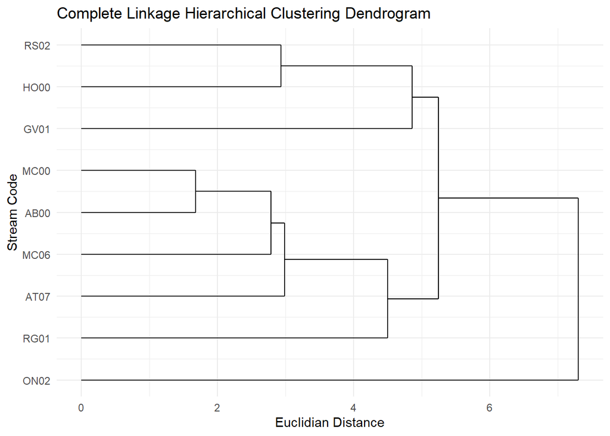

```r
### scale the data
stream_scaled <- stream %>%
  select(2:11) %>% # remove stream code so we can scale only numbers
  scale()

### add the stream code back in as a row name
rownames(stream_scaled) <- stream$site_code

### euclidean distance
euc_distance <- dist(stream_scaled, method = "euclidean")
#euc_distance

#### Perform hierarchical clustering by complete linkage with `stats::hclust()`
hc_complete <- hclust(euc_distance, method = "complete" )

### Plot it
ggdendrogram(hc_complete,
             rotate = TRUE) +
  theme_minimal() +
  labs(x = "Stream Code", y = "Euclidian Distance")+
  ggtitle("Complete Linkage Hierarchical Clustering Dendrogram")
```

**Figure 1: Dendrogram for Stream Chemistry in Santa Barbara County** Agglomerative hierarchical clustering dendrogram representing the similarities/dissimilarities in the data. This was performed using complete linkage and Euclidean distance.

# Summary

- Stream ON02 has its own branch on the dendrogram, indicating that it has the most different chemical properties.
- MC00 and AB00 are in the most nested cluster. These two streams must have highly similar stream chemical properties.
- The number of clusters can be determined based on the desired minimum euclidean distance and a horizontal slice in the dendrogram. Further research can be done to determine exact chemical properties and environmental factors leading to dissimilarities.

# Citation

**Data Citation:** Santa Barbara Coastal LTER and J. Melack. 2019. SBC LTER: Land: Stream chemistry in the Santa Barbara Coastal drainage area, ongoing since 2000 ver 16. Environmental Data Initiative.